# 1731国控站点污染物数据质量报告

### 一、 总述

此报告基于全国除港澳台以外**31**省市自治区**6种**大气污染物（PM2.5、PM10、SO2、NO2、CO、O3）浓度月度平均数据，对1731个国控站点进行数据质量评估。数据集共计91,420条记录，时间跨度为2013年-2018年，每条记录包含某站点某月的6种大气污染物平均浓度，标准差和缺失率。**本报告评估内容主要集中在数据缺失和污染物浓度波动水平两个方面。**  
各国控站对大气污染物浓度监测的原始数据是**按小时记录的。**为探究污染物浓度数据缺失情况与波动水平随时间、季节变化情况，对各站点各污染物原始数据**按月份为单位分组**，并计算以下变量：

| 变量名称 | 单位 | 变量含义及计算方法 |
| --- | --- | --- |
| 当月应有观测数 | 次 | 如对有31天的月份，当月应有观测$31\times 24=744$次 |
| 当月实际观测数 | 次 | 当月应有观测数-当月缺失观测数 |
| 当月污染物浓度观测缺失率 | – | (当月应有观测数-当月实际观测数)/当月应有观测数 |
| 当月污染物浓度平均值 | $\mu g/m^3$ | 当月该种污染物浓度实际观测平均值 |
| 当月污染物浓度标准差 | $\mu g/m^3$ | 当月该种污染物浓度实际观测标准差 |
| 当月污染物浓度变异系数 | – | 当月污染物浓度标准差/当月污染物浓度平均值 |

在计算上述各变量时，对数据进行如下处理：

- 计算各站点各年的缺失率时，将年平均缺失率**高于30%**的站点的该年数据从数据集中剔除；
- 数据中所涉及观测缺失的含义为该站点未采集到当前小时该污染物浓度数据，即污染物浓度异常并不计为缺失；
- 变异系数（CV）反映污染物浓度波动水平，污染物浓度异常会对CV的计算造成影响，因此在计算CV时剔除浓度异常数据。

本报告中将31个省市自治区按照中国地理地区划分为7大地区（东北、华北、华中、华东、华南、西南、西北）进行研究，各地区包含的省市自治区及国控站数目如表2所示：

表2：各地区划分及国控站数目统计

| 地区 | 省份 | 国控站总数 |
| --- | --- | --- |
| 东北 | 黑龙江、吉林、辽宁 | 217 |
| 华东 | 上海、江苏、浙江、安徽、福建、江西、山东 | 217 |
| 华北 | 北京、天津、山西、河北、内蒙古 | 480 |
| 华中 | 河南、湖北、湖南 | 173 |
| 华南 | 广东、广西、海南 | 220 |
| 西南 | 重庆、四川、贵州、云南、西藏 | 189 |
| 西北 | 陕西、甘肃、青海、宁夏、新疆 | 235 |

对数据集各年有效观测数进行统计，结果如表3所示：

表3：所有国控站各年观测总计

| 年份 | 观察总数 |
| --- | --- |
| 2013 | 6486 |
| 2014 | 12081 |
| 2015 | 18022 |
| 2016 | 17999 |
| 2017 | 18168 |
| 2018 | 18664 |

### 二、缺失率整体分析

#### 1. 各地区历年污染物平均缺失率概况

这部分整体考察各地区数据缺失率的逐年变化规律，首先综合所有7个地区的数据，计算各年所有污染物平均缺失率如图1所示。**总体来看，年缺失率呈现先下降后上升的趋势**，2013年整体缺失率达到11.23%，缺失率在2016年达到最低，而在近两年缺失率又有所回弹。

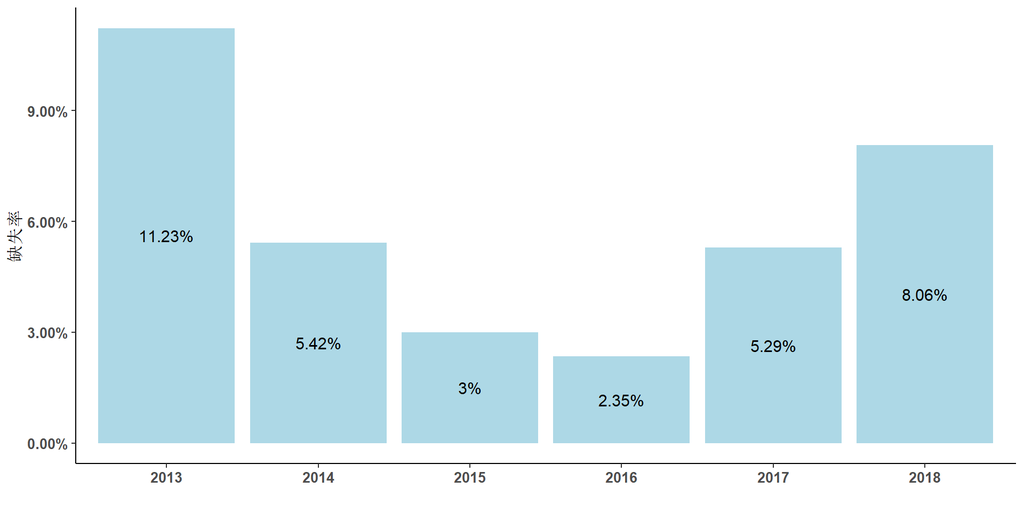

图1 各年份(2013-2018)缺失率总计

下面考察不同年份各个地区污染物平均缺失率的数据，以观察不同地区之间数据缺失情况的差异，如图2所示。从图中可以看出：

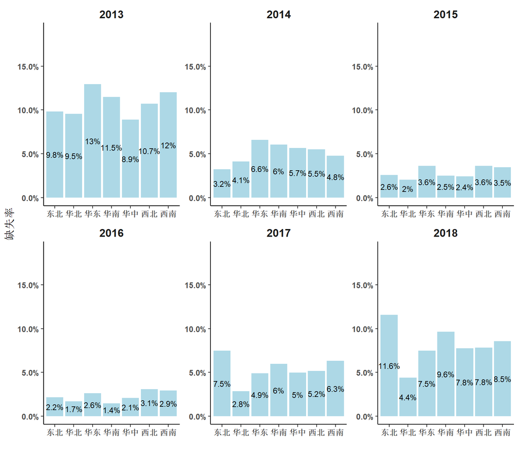

图2 各地区分年份（2013-2018）缺失率统计

#### 2. 各污染物历年平均缺失率概况

- 综合2013-2018各污染物的缺失率数据，分别计算各污染物的平均缺失率，可以看出PM10的缺失情况最严重，其次为SO2，其他污染物平均缺失率均低于5%。

表4：各污染物缺失率历年平均值

| 污染物 | 缺失率平均值(%) |
| --- | --- |
| PM2.5 | 4.89 |
| PM10 | 7.12 |
| SO2 | 5.29 |
| NO2 | 4.76 |
| O3 | 4.48 |
| CO | 4.38 |

- 各污染物历年平均缺失率也呈现先下降后上升的趋势，该趋势和所有污染物整体缺失率的变化趋势一致。注意到**PM10**近两年的缺失率**明显高于**其他污染物。

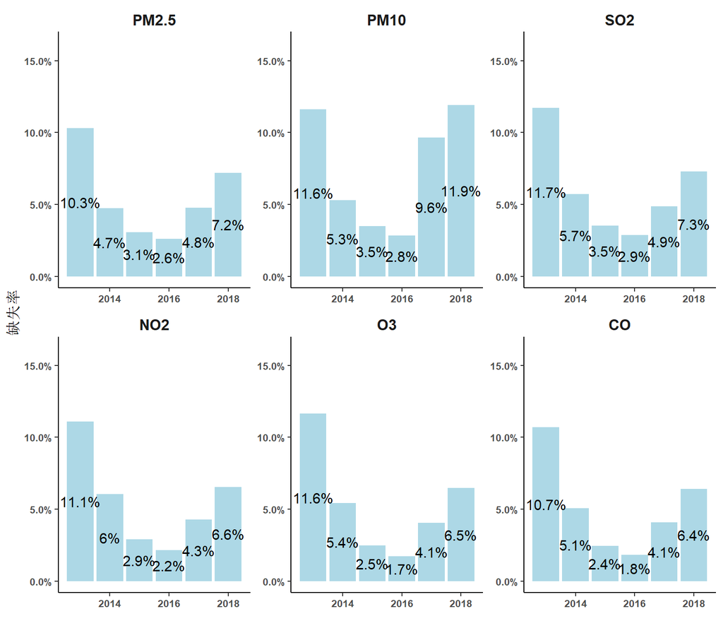

  图3 各污染物分年份（2013-2018）缺失率统计

#### 3. 污染物平均缺失率季节分布

AVG表示：当月七地区六种污染物的缺失率均值（计算时取算术平均数）；

图4绘制的各污染物不同季节的平均缺失率统计图，从缺失率的季节分布来看，**春季（2月份和3月份）**缺失率**较低**，**夏秋季节（8月份和9月份）**缺失率**较高**。

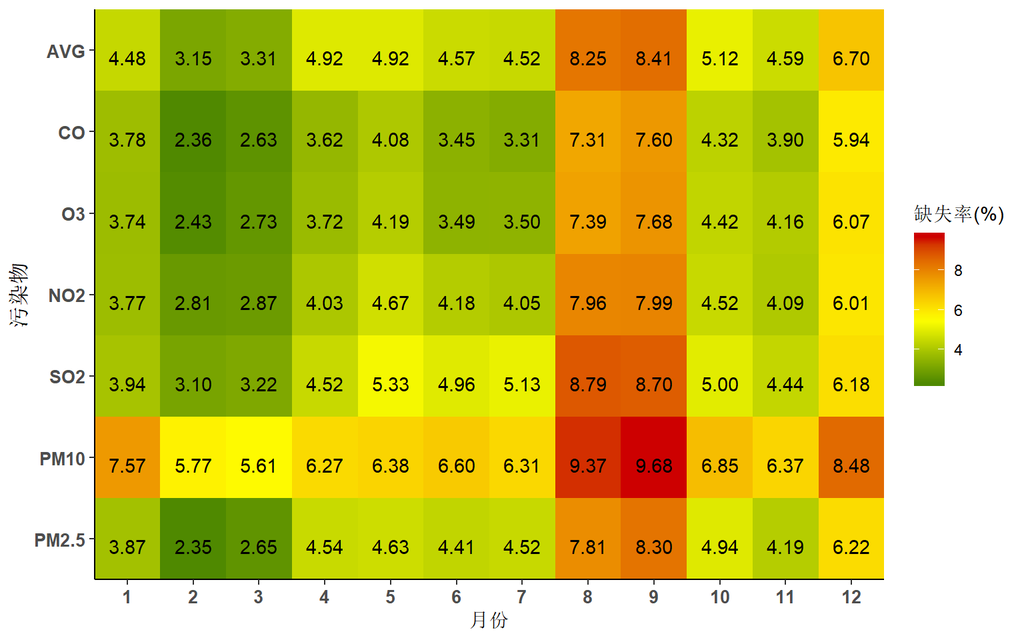

图4 各月份各污染物缺失率统计

#### 4. 各地区不同污染物缺失率平均水平比较

AVG是指：各地区2013-2018年六种污染物缺失率的均值（计算时取算术平均数）；

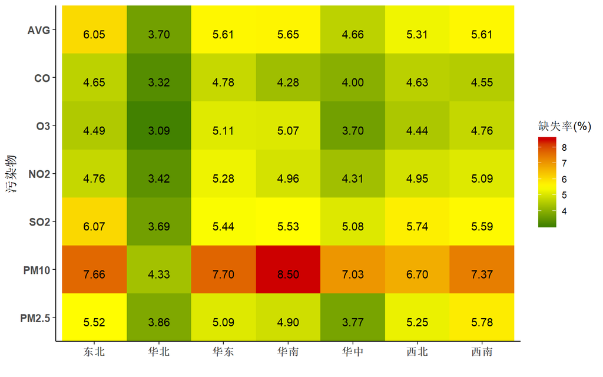

图5 各地区分污染物平均缺失率统计（2013-2018）

图6详细列举了7个地区分污染物的逐年缺失情况。可以看出：

- **2013年各个地区**的数据缺失情况都较为**严重**，半数以上污染物缺失率超过10%，2014年起得到了较大的改善；
- **2016年**各地区各污染物缺失达到**最低**，大部分污染物缺失率低于3%；
- 2017和2018年各地区污染物缺失率出现**回弹**，其中**东北地区**缺失率上升最明显；
- 2017和2018年各地区**PM10**缺失均较为严重，较之前年份明显上升，很多地区都出现PM10缺失率高于10%的情况，以**东北、华南**两个地区最为严重。

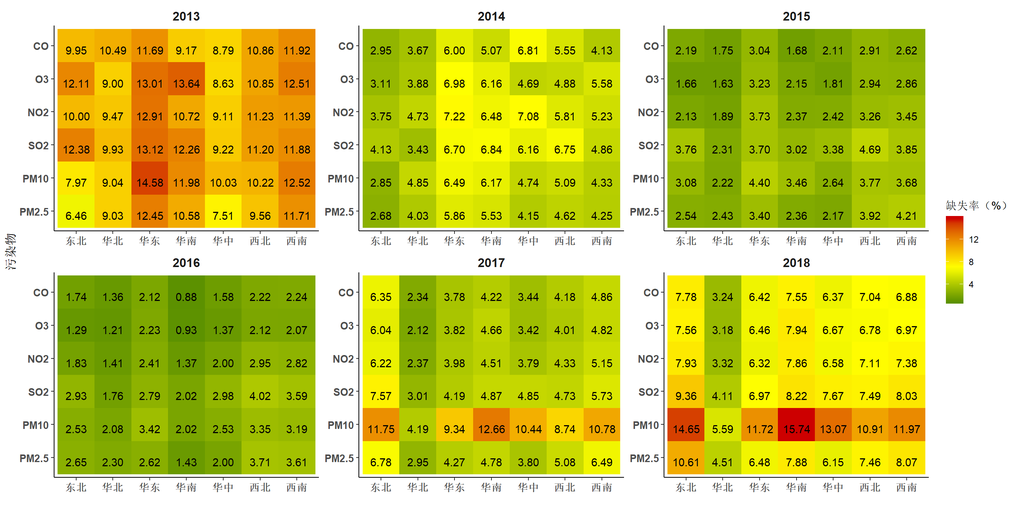

图6 各地区分污染物缺失率（%）逐年变化情况

### 三、变异系数(CV)整体分析

#### 1. 各地区不同污染物浓度波动水平比较

对不同污染物缺失率平均水平进行分析后，我们通过计算各种污染物浓度的变异系数比较不同量纲的指标的波动程度。波动程度用**变异系数(CV)**衡量，变异系数是指原始数据的标准差与其平均数的比值，本报告中即：**污染物浓度标准差/污染物浓度均值**。各个地区不同污染物变异系数的逐年变化情况如图7所示。从图7可以看出：

- 大多数污染物浓度的波动程度并未随着年份呈现明显的上升或下降的趋势，SO2的浓度波动程度在各地区有逐年减缓的趋势；
- 6种污染物中，**SO2**的波动幅度**相对较大**，**CO**的波动幅度**相对较小；**
- **东北、西北、华北**地区，污染物浓度（尤其是PM10和PM2.5）波动幅度相对较大；
- 有一些值得注意的现象，比如**华南地区CO**浓度的波动程度明显低于其他地区并且也小于该地区的其他污染物；**2018年华北地区的SO2**波动幅度**明显上升。**

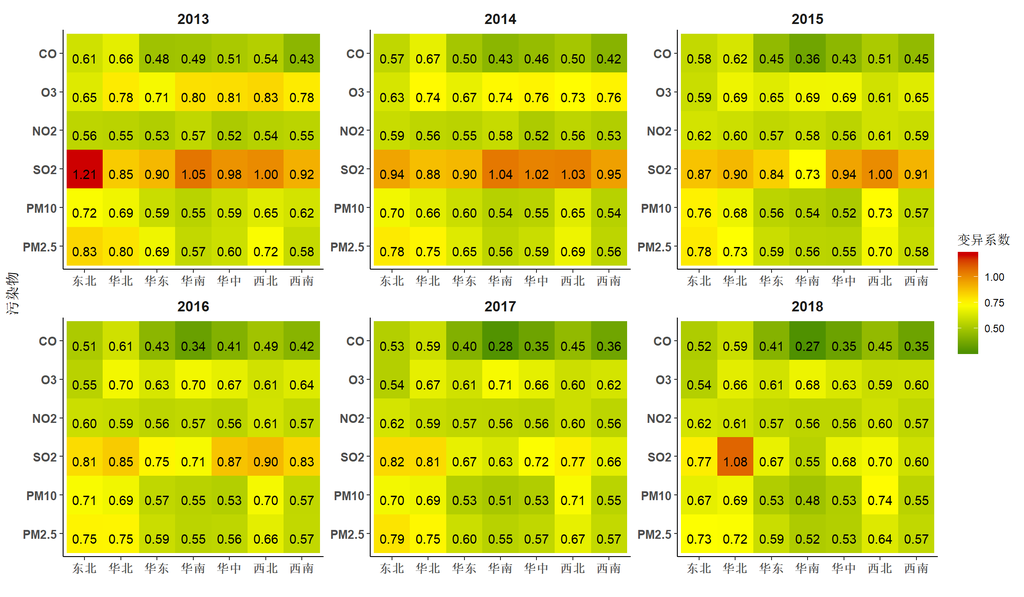

图7 各地区分污染物波动程度（变异系数）逐年变化情况

### 四、缺失率&变异系数(CV)站点排名

了解各地区污染物缺失和数据波动整体情况之后，为了详细探究数据缺失和波动情况的空间分布规律，我们依照各个站点的平均缺失率以及PM2.5变异系数对站点进行排名，结果如下：

##### 1. 2015-2018年各站点污染物缺失率排名

根据缺失率排名结果，可以得到以下结论：

2015年平均缺失率最高10站点

|  | 站点名 | 地区 | 省份 | 平均缺失率（%） | PM2.5 | PM10 | SO2 | NO2 | O3 | CO |
| --- | --- | --- | --- | --- | --- | --- | --- | --- | --- | --- |
| 1 | 茫荡山 | 华东 | 福建 | 27.77 | 24.66 | 38.01 | 17.55 | 25.90 | 29.54 | 20.92 |
| 2 | 空港物流加工区 | 华北 | 天津 | 27.45 | 26.90 | 30.54 | 26.66 | 26.73 | 26.53 | 27.32 |
| 3 | 将军桥 | 西南 | 四川 | 25.61 | 25.59 | 29.64 | 24.97 | 23.77 | 25.05 | 24.61 |
| 4 | 电视发射台 | 华中 | 湖南 | 24.84 | 24.18 | 28.23 | 24.42 | 23.60 | 24.81 | 23.83 |
| 5 | 昌都地区昌都坝 | 西南 | 西藏 | 23.67 | 29.19 | 46.18 | 20.35 | 26.10 | 18.85 | 17.86 |
| 6 | 市艺校 | 华北 | 内蒙古 | 23.56 | 23.72 | 23.10 | 25.25 | 23.01 | 23.17 | 23.10 |
| 7 | 辛集市政府 | 华北 | 河北 | 21.55 | 21.62 | 21.68 | 21.60 | 21.46 | 21.49 | 21.46 |
| 8 | 广南水库 | 华东 | 山东 | 20.32 | 19.67 | 19.83 | 21.27 | 22.16 | 19.42 | 19.58 |
| 9 | 益益乳业工业园 | 华东 | 安徽 | 20.20 | 23.22 | 19.32 | 18.29 | 18.35 | 19.77 | 22.23 |
| 10 | 定州武装部 | 华北 | 河北 | 19.63 | 19.53 | 19.24 | 19.46 | 20.13 | 20.28 | 19.13 |

2016年平均缺失率最高10站点

|  | 站点名 | 地区 | 省份 | 平均缺失率（%） | PM2.5 | PM10 | SO2 | NO2 | O3 | CO |
| --- | --- | --- | --- | --- | --- | --- | --- | --- | --- | --- |
| 1 | 宝龙广场 | 华东 | 江苏 | 28.55 | 28.64 | 28.36 | 28.50 | 28.78 | 28.45 | 28.59 |
| 2 | 胡沟管理处 | 华东 | 江苏 | 27.88 | 27.56 | 28.34 | 27.88 | 27.88 | 27.88 | 27.75 |
| 3 | 王营 | 华东 | 江苏 | 27.45 | 27.80 | 27.48 | 27.42 | 27.38 | 27.29 | 27.34 |
| 4 | 矿山设计院 | 华东 | 江苏 | 26.31 | 26.66 | 26.08 | 26.21 | 26.22 | 26.58 | 26.13 |
| 5 | 沉湖七壕 | 华中 | 湖北 | 25.44 | 25.43 | 27.87 | 25.41 | 24.96 | 25.39 | 23.59 |
| 6 | 菱塘子站 | 华东 | 江苏 | 25.34 | 15.58 | 16.54 | 14.80 | 15.00 | 68.42 | 21.69 |
| 7 | 德源药业 | 华东 | 江苏 | 25.23 | 25.04 | 25.27 | 25.23 | 25.23 | 25.37 | 25.23 |
| 8 | 海门市监测站 | 华东 | 江苏 | 23.97 | 22.14 | 30.65 | 20.99 | 20.82 | 33.00 | 20.81 |
| 9 | 石化 | 华东 | 江西 | 23.55 | 24.62 | 24.99 | 22.70 | 22.24 | 23.31 | 23.43 |
| 10 | 兖州教体局 | 华东 | 山东 | 23.48 | 23.45 | 22.92 | 23.38 | NaN | 25.11 | 22.54 |

2017年平均缺失率最高10站点

|  | 站点名 | 地区 | 省份 | 平均缺失率(%) | PM2.5 | PM10 | SO2 | NO2 | O3 | CO |
| --- | --- | --- | --- | --- | --- | --- | --- | --- | --- | --- |
| 1 | 连山区政府 | 东北 | 辽宁 | 29.99 | 27.64 | 40.99 | 27.71 | 27.50 | 28.42 | 27.71 |
| 2 | 职业病院 | 东北 | 辽宁 | 29.85 | 29.85 | 40.03 | 27.24 | 27.27 | 27.48 | 27.24 |
| 3 | 面粉厂 | 东北 | 辽宁 | 29.84 | 28.63 | 32.32 | 36.14 | 27.03 | 27.91 | 27.03 |
| 4 | 金阳区 | 西南 | 贵州 | 29.83 | 34.38 | 33.47 | 27.66 | 28.34 | 27.69 | 27.42 |
| 5 | 元宝山水厂 | 东北 | 辽宁 | 29.66 | 28.56 | 28.75 | 35.20 | 28.91 | 28.42 | 28.11 |
| 6 | 葫芦岛市西山坡 | 东北 | 辽宁 | 29.49 | 27.14 | 39.41 | 28.59 | 27.47 | 27.20 | 27.13 |
| 7 | 社会福利院 | 华东 | 江苏 | 29.47 | 28.87 | 33.26 | 28.40 | 28.63 | 29.48 | 28.18 |
| 8 | 炮兵学院 | 东北 | 辽宁 | 29.46 | 28.91 | 31.98 | 28.87 | 29.18 | 28.91 | 28.91 |
| 9 | 望花 | 东北 | 辽宁 | 29.34 | 28.46 | 35.21 | 28.13 | 27.94 | 28.57 | 27.73 |
| 10 | 化工医院 | 东北 | 辽宁 | 29.30 | 28.86 | 36.97 | 28.24 | 26.83 | 27.53 | 27.37 |

2018年平均缺失率最高19站点

|  | 站点名 | 地区 | 省份 | 平均缺失率(%) | PM2.5 | PM10 | SO2 | NO2 | O3 | CO |
| --- | --- | --- | --- | --- | --- | --- | --- | --- | --- | --- |
| 1 | 一建构建厂 | 东北 | 辽宁 | 29.67 | 26.59 | 32.74 | NaN | NaN | NaN | NaN |
| 2 | 南岗学府路 | 东北 | 黑龙江 | 29.64 | 27.24 | 31.83 | 28.86 | 28.18 | 28.72 | 33.02 |
| 3 | 连山区政府 | 东北 | 辽宁 | 29.44 | 24.92 | 33.96 | NaN | NaN | NaN | NaN |
| 4 | 中新生态城 | 华北 | 天津 | 29.35 | 24.40 | 34.30 | NaN | NaN | NaN | NaN |
| 5 | 继电器厂 | 华北 | 天津 | 29.32 | 23.06 | 35.57 | NaN | NaN | NaN | NaN |
| 6 | 东丽中学 | 华北 | 天津 | 29.29 | 23.24 | 35.34 | NaN | NaN | NaN | NaN |
| 7 | 金沙江 | 东北 | 辽宁 | 29.14 | 27.83 | 30.46 | NaN | NaN | NaN | NaN |
| 8 | 泰丰工业园 | 华北 | 天津 | 28.87 | 22.83 | 34.91 | NaN | NaN | NaN | NaN |
| 9 | 河东站 | 华北 | 天津 | 28.76 | 22.35 | 35.18 | NaN | NaN | NaN | NaN |
| 10 | 本站 | 东北 | 辽宁 | 28.71 | 26.89 | 30.52 | NaN | NaN | NaN | NaN |
| 11 | 玉龙新城子站 | 东北 | 辽宁 | 28.61 | 26.73 | 30.50 | NaN | NaN | NaN | NaN |
| 12 | 新区公园 | 东北 | 辽宁 | 28.56 | 26.70 | 30.43 | NaN | NaN | NaN | NaN |
| 13 | 乌当区 | 西南 | 贵州 | 28.23 | 24.26 | 32.20 | NaN | NaN | NaN | NaN |
| 14 | 市自来水厂 | 华南 | 广东 | 28.04 | 23.02 | 33.07 | NaN | NaN | NaN | NaN |
| 15 | 河源中学 | 华南 | 广东 | 28.03 | 24.45 | 31.61 | NaN | NaN | NaN | NaN |
| 16 | 龙城农业园区 | 东北 | 辽宁 | 27.72 | 24.84 | 30.59 | NaN | NaN | NaN | NaN |
| 17 | 葫芦岛市西山坡 | 东北 | 辽宁 | 27.68 | 23.37 | 31.99 | NaN | NaN | NaN | NaN |
| 18 | 百股水厂 | 东北 | 辽宁 | 27.32 | 24.14 | 30.50 | NaN | NaN | NaN | NaN |
| 19 | 渔湖初级中学 | 华南 | 广东 | 27.11 | 22.37 | 31.85 | NaN | NaN | NaN | NaN |

##### 2. 2015-2018年各站点污染物浓度波动水平排名

2015年PM2.5变异系数最高10站点

|  | 站点名 | 地区 | 省份 | PM2.5变异系数 | PM10变异系数 | SO2变异系数 | NO2变异系数 | O3变异系数 | CO变异系数 |
| --- | --- | --- | --- | --- | --- | --- | --- | --- | --- |
| 1 | 公司二招 | 西北 | 甘肃 | 1.24 | 0.95 | 1.89 | 0.74 | 0.37 | 0.56 |
| 2 | 新川苑 | 西北 | 甘肃 | 1.21 | 1.03 | 1.92 | 0.75 | 0.37 | 0.70 |
| 3 | 酒钢耐材公司 | 西北 | 甘肃 | 1.20 | 1.06 | 1.57 | 0.58 | 0.31 | 0.90 |
| 4 | 昌都监测站 | 西南 | 西藏 | 1.19 | 0.84 | 0.41 | 1.04 | 0.45 | 0.47 |
| 5 | 益益乳业工业园 | 华东 | 安徽 | 1.09 | 0.53 | 1.72 | 0.81 | 0.73 | 0.53 |
| 6 | 公安局 | 东北 | 黑龙江 | 1.08 | 0.80 | 0.63 | 0.82 | 0.44 | 0.78 |
| 7 | 富区环保局 | 东北 | 黑龙江 | 1.06 | 0.77 | 1.18 | 0.72 | 0.47 | 1.12 |
| 8 | 市科委 | 西北 | 甘肃 | 1.04 | 1.05 | 2.00 | 0.84 | 0.38 | 0.67 |
| 9 | 天山天池 | 西北 | 新疆 | 1.04 | 1.38 | 0.90 | 0.65 | 0.38 | 0.82 |
| 10 | 玉树县结古镇 | 西北 | 青海 | 1.04 | 0.88 | 2.54 | 0.48 | 0.52 | 0.54 |

2016年PM2.5变异系数最高10站点

|  | 站点名 | 地区 | 省份 | PM2.5变异系数 | PM10变异系数 | SO2变异系数 | NO2变异系数 | O3变异系数 | CO变异系数 |
| --- | --- | --- | --- | --- | --- | --- | --- | --- | --- |
| 1 | 天义路 | 华北 | 内蒙古 | 1.09 | 0.86 | 1.05 | 0.73 | 0.43 | 0.55 |
| 2 | 酒钢宾馆 | 西北 | 甘肃 | 1.08 | 1.02 | 1.63 | 0.66 | 0.28 | 0.88 |
| 3 | 阿里监测站 | 西南 | 西藏 | 1.06 | 1.10 | 0.52 | 0.79 | 0.38 | 0.43 |
| 4 | 地震局 | 东北 | 黑龙江 | 1.04 | 0.95 | 0.81 | 0.55 | 0.38 | 0.40 |
| 5 | 定陵 | 华北 | 北京 | 1.03 | 0.86 | 0.90 | 0.81 | 0.66 | 0.77 |
| 6 | 昌都监测站 | 西南 | 西藏 | 1.02 | 0.94 | 0.43 | 1.34 | 0.51 | 0.50 |
| 7 | 日喀则监测站 | 西南 | 西藏 | 1.02 | 1.09 | 0.41 | 0.78 | 0.44 | 0.69 |
| 8 | 五金库 | 华北 | 河北 | 1.02 | 0.76 | 0.60 | 0.62 | 0.48 | 0.78 |
| 9 | 阿里地委 | 西南 | 西藏 | 1.01 | 1.16 | 0.72 | 0.90 | 0.28 | 0.44 |
| 10 | 龙港区 | 东北 | 辽宁 | 1.01 | 0.77 | 1.42 | 0.74 | 0.47 | 0.64 |
| 11 | 马园 | 西北 | 宁夏 | 1.01 | 0.90 | 0.66 | 0.66 | 0.43 | 0.41 |

2017年PM2.5变异系数最高10站点

|  | 站点名 | 地区 | 省份 | PM2.5变异系数 | PM10变异系数 | SO2变异系数 | NO2变异系数 | O3变异系数 | CO变异系数 |
| --- | --- | --- | --- | --- | --- | --- | --- | --- | --- |
| 1 | 集宁旧区西 | 华北 | 内蒙古 | 1.59 | 1.32 | 0.45 | 0.70 | 0.53 | 0.84 |
| 2 | 酒钢宾馆 | 西北 | 甘肃 | 1.21 | 1.20 | 1.78 | 0.63 | 0.28 | 0.82 |
| 3 | 科右前旗环保局 | 华北 | 内蒙古 | 1.11 | 0.99 | 0.92 | 0.96 | 0.45 | 1.04 |
| 4 | 五金库 | 华北 | 河北 | 1.11 | 0.78 | 0.66 | 0.67 | 0.40 | 0.58 |
| 5 | 地震局 | 东北 | 黑龙江 | 1.10 | 0.97 | 0.67 | 0.59 | 0.38 | 0.46 |
| 6 | 仰口 | 华东 | 山东 | 1.10 | 0.71 | 0.89 | 0.63 | 0.37 | 0.46 |
| 7 | 富区环保局 | 东北 | 黑龙江 | 1.08 | 0.84 | 0.80 | 0.67 | 0.42 | 0.47 |
| 8 | 盟监测站 | 华北 | 内蒙古 | 1.08 | 1.12 | 1.57 | 0.68 | 0.45 | 0.98 |
| 9 | 人和东街 | 东北 | 黑龙江 | 1.07 | 0.93 | 0.81 | 0.67 | 0.44 | 0.49 |
| 10 | 党政办公中心 | 东北 | 黑龙江 | 1.06 | 1.06 | 0.80 | 0.72 | 0.40 | 0.61 |
| 11 | 公司二招 | 西北 | 甘肃 | 1.06 | 1.08 | 1.98 | 0.86 | 0.30 | 0.69 |
| 12 | 市人民政府 | 西北 | 新疆 | 1.06 | 0.99 | 1.65 | 0.78 | 0.25 | 0.46 |
| 13 | 玉树县结古镇 | 西北 | 青海 | 1.06 | 0.79 | 0.98 | 0.76 | 0.38 | 0.32 |

2018年PM2.5变异系数最高20站点

|  | 站点名 | 地区 | 省份 | PM2.5变异系数 | PM10变异系数 | SO2变异系数 | NO2变异系数 | O3变异系数 | CO变异系数 |
| --- | --- | --- | --- | --- | --- | --- | --- | --- | --- |
| 1 | 康泽苑 | 华北 | 内蒙古 | 1.21 | 1.09 | 0.48 | 0.55 | 0.44 | 0.31 |
| 2 | 市环保监测站 | 华北 | 内蒙古 | 1.13 | 1.52 | 0.49 | 0.81 | 0.35 | 0.68 |
| 3 | 市环保大楼 | 华北 | 内蒙古 | 1.09 | 1.05 | 1.03 | 0.74 | 0.41 | 0.62 |
| 4 | 酒钢宾馆 | 西北 | 甘肃 | 1.05 | 1.02 | 1.63 | 0.65 | 0.30 | 0.80 |
| 5 | 公司二招 | 西北 | 甘肃 | 1.02 | 1.16 | 1.93 | 0.83 | 0.32 | 0.74 |
| 6 | 集宁新区 | 华北 | 内蒙古 | 1.00 | 1.09 | 0.42 | 0.67 | 0.41 | 0.63 |
| 7 | 沙坡头消防站 | 西北 | 宁夏 | 1.00 | 1.14 | 0.75 | 0.69 | 0.44 | 0.34 |
| 8 | 双合村 | 东北 | 黑龙江 | 1.00 | 0.93 | 1.44 | 0.79 | 0.48 | 1.35 |
| 9 | 定陵 | 华北 | 北京 | 0.98 | 0.82 | 1.08 | 0.70 | 0.57 | 0.69 |
| 10 | 怀柔镇 | 华北 | 北京 | 0.98 | 0.82 | 2.30 | 0.63 | 0.59 | 0.67 |
| 11 | 白酒厂 | 东北 | 黑龙江 | 0.97 | 0.87 | 0.83 | 0.68 | 0.53 | 0.77 |
| 12 | 附中 | 华北 | 内蒙古 | 0.97 | 0.99 | 1.19 | 0.77 | 0.42 | 0.54 |
| 13 | 市人民政府 | 西北 | 新疆 | 0.97 | 0.82 | 1.00 | 0.95 | 0.30 | 0.35 |
| 14 | 五金库 | 华北 | 河北 | 0.97 | 0.93 | 1.71 | 0.70 | 0.44 | 0.49 |
| 15 | 党政办公中心 | 东北 | 黑龙江 | 0.96 | 0.88 | 0.67 | 0.69 | 0.34 | 0.41 |
| 16 | 二十九中 | 华北 | 内蒙古 | 0.94 | 0.88 | 0.47 | 0.62 | 0.63 | 0.35 |
| 17 | 高级中学 | 西北 | 宁夏 | 0.94 | 0.95 | 0.84 | 0.66 | 0.50 | 0.61 |
| 18 | 华泰汽车城 | 华北 | 内蒙古 | 0.94 | 0.98 | 0.54 | 0.64 | 0.50 | 0.33 |
| 19 | 那曲会议中心 | 西南 | 西藏 | 0.94 | 0.93 | 0.51 | 1.02 | 0.43 | 0.52 |
| 20 | 秋林养殖基地 | 华北 | 内蒙古 | 0.94 | 1.03 | 0.79 | 0.55 | 0.42 | 0.37 |
| 21 | 顺义新城 | 华北 | 北京 | 0.94 | 0.78 | 0.81 | 0.66 | 0.73 | 0.63 |
| 22 | 兴松小区 | 华北 | 内蒙古 | 0.94 | 0.87 | 0.48 | 0.66 | 0.67 | 0.53 |